# Simple Linear Regression - Intro+Formalization

Notes and in-class exercises

You can download the .qmd file for this activity here and open in R-studio. The rendered version is posted in the [course website](https://mutasim221b.github.io/Mac-STAT-155-Sp-26/) (Activities tab). I often experiment with the class activities (and see it in live!) and make updates, but I always post the final version before class starts. To be sure you have the most up-to-date copy, please download it once you’ve settled in before class begins.

# Bill is out of town on Monday, Feb 02- No class! We will resume our class meetings on Wednesday, Feb 4

# Notes

## Learning goals

By the end of this lesson, you should be able to:

- Visualize and describe the relationship between two **quantitative** variables using a **scatterplot**
- Write R code to create a scatterplot and compute the linear **correlation** between two quantitative variables
- Describe/identify **weak** / **strong**, and **positive** / **negative** correlation from a point cloud
- Build intuition for fitting **lines** to quantify the relationship between two quantitative variables
- Differentiate between a **response** / **outcome variable** and a **predictor** / **explanatory variable**
- Write a **model formula** for a simple linear regression model with a quantitative predictor
- Write R code to fit a linear regression model
- Interpret the **intercept** and **slope** coefficients in a simple linear regression model with a quantitative predictor
- Compute **expected / predicted / fitted values** and **residuals** from a linear regression model formula
- Interpret predicted values and residuals in the context of the data
- Explain the connection between residuals and the **least squares criterion**

## Readings and videos

Choose either the reading or the videos to go through **before** class. **CP Quiz due at 09:00 am** on these topics

- Reading: Sections 2.8, 3.1-3.3, 3.6 in the [STAT 155 Notes](https://mac-stat.github.io/Stat155Notes/)
- Videos:
  - [Simple linear regression Part 1: motivation & scatterplots](https://youtu.be/ghweQRQE0yw)
  - [Simple linear regression Part 2: correlation](https://youtu.be/S6sgLrROfNw)
  - [Simple linear regression Part 3: simple linear regression models](https://youtu.be/cwxUNJUYKsA)
  - [R Code for Fitting a Linear Model](https://voicethread.com/share/14928147/) (Time: 11:07)

**File organization:** Save this file in the “Activities” subfolder of your “STAT155” folder.

# Exercises

**Context:** Today we’ll explore data from [Capital Bikeshare](https://capitalbikeshare.com/), a company in Washington DC. Our main goal will be to explore daily ridership among registered users, as measured by `riders_registered`. Read in the data below.

```r
# Load packages and import data
library(readr)
library(ggplot2)
library(dplyr)

bikes <- read_csv("https://mac-stat.github.io/data/bikeshare.csv")
```

## Exercise 1: Get to know the data

Create a new code chunk to look at the first few rows of the data and learn how much data (in terms of cases and variables) we have.

```r
dim(bikes)
## [1] 731  15
head(bikes)
## # A tibble: 6 × 15
##   date       season  year month day_of_week weekend holiday temp_actual
##   <date>     <chr>  <dbl> <chr> <chr>       <lgl>   <chr>         <dbl>
## 1 2011-01-01 winter  2011 Jan   Sat         TRUE    no             57.4
## 2 2011-01-02 winter  2011 Jan   Sun         TRUE    no             58.8
## 3 2011-01-03 winter  2011 Jan   Mon         FALSE   no             46.5
## 4 2011-01-04 winter  2011 Jan   Tue         FALSE   no             46.8
## 5 2011-01-05 winter  2011 Jan   Wed         FALSE   no             48.7
## 6 2011-01-06 winter  2011 Jan   Thu         FALSE   no             47.1
## # ℹ 7 more variables: temp_feel <dbl>, humidity <dbl>, windspeed <dbl>,
## #   weather_cat <chr>, riders_casual <dbl>, riders_registered <dbl>,
## #   riders_total <dbl>
```

1. What does a case represent?
2. How many and what kinds of variables do we have?

## Exercise 2: Get to know the outcome/response variable

Let’s get acquainted with the `riders_registered` variable.

- Construct an appropriate plot to visualize the distribution of this variable, and compute appropriate numerical summaries.

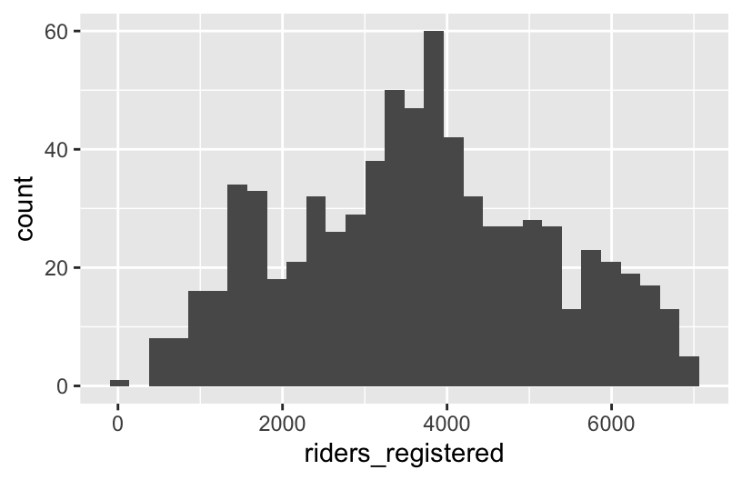

```r
ggplot(bikes, aes(x = riders_registered)) +
    geom_histogram()
```

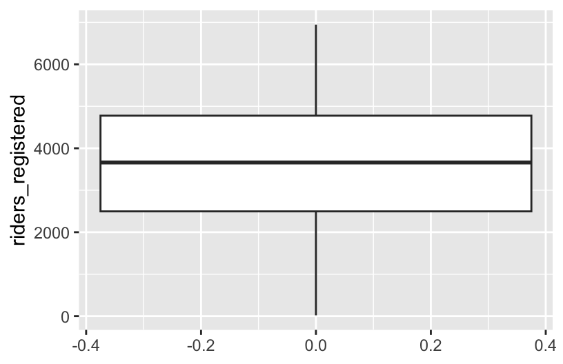

```r
ggplot(bikes, aes(y = riders_registered)) +
    geom_boxplot()
```

```r
summary(bikes$riders_registered)
##    Min. 1st Qu.  Median    Mean 3rd Qu.    Max.
##      20    2497    3662    3656    4776    6946

bikes %>%
    summarize(sd(riders_registered))
## # A tibble: 1 × 1
##   `sd(riders_registered)`
##                     <dbl>
## 1                   1560.
```

- Write a good paragraph interpreting the plot and numerical summaries after the class.

> Type your answer

## Before starting the next Exercise, let’s do the followings first!

**Answers**

It creates code chunks

## Exercise 3: Explore the relationship between ridership and temperature

We’d like to understand how daily ridership among registered users relates with the temperature that it feels like that day (`temp_feel`).

1. What type of plot would be appropriate to visualize this relationship? Sketch and describe what you expect this plot to look like.

> Scatterplot (outcome and predictor are both quantitative)
2. Create an appropriate plot using `ggplot()`. How does the plot compare to what you predicted?

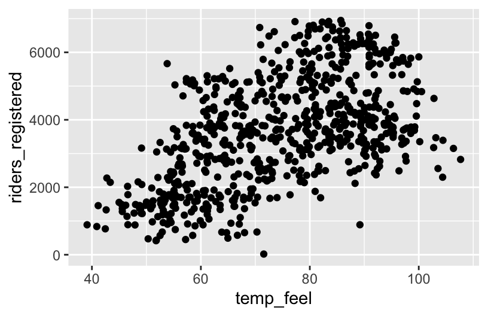

```r
ggplot(bikes, aes(x = temp_feel, y = riders_registered)) +
    geom_point()
```

**Comments**

Trend: Linear (?); Direction/Association: Positive/Negative, Strength: spread of the points (dispersed? close together? moderately close together?); Outlier?

```r
# Add a red straight line of best fit and a blue curve of best fit
YOUR_PLOT +
    geom_smooth(method = "lm", color = "red", se = FALSE) +
    geom_smooth(color = "blue", se = FALSE)
```

What do you think “eval = TRUE/FALSE” doing here **{r eval = TRUE/FALSE}**?

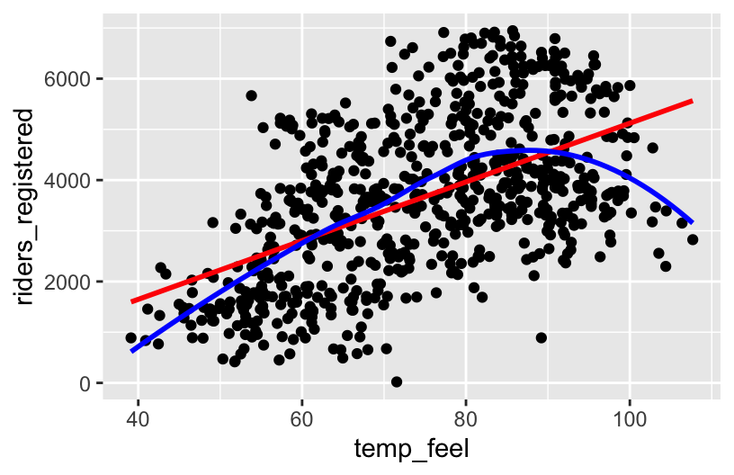

```r
# Add a red straight line of best fit and a blue curve of best fit
ggplot(bikes, aes(x = temp_feel, y = riders_registered)) +
    geom_point() +
    geom_smooth(method = "lm", color = "red", se = FALSE) +
    geom_smooth(color = "blue", se = FALSE)
```

**Comments:** If we only displayed the red line of best fit on the plot, we might miss the slight downward trend at the highest temperatures that we can see more clearly with the blue curve of best fit. A linear model is not appropriate if fit to the whole range of the data, but there does seem to be a linear relationship between ridership and temperature below 80 degrees Fahrenheit.

4. Compute Correlation of temp_feel and riders_registered.

### Correlation

We can quantify the **linear** relationship between two quantitative variables using a numerical summary known as **correlation** (sometimes known as a “correlation coefficient” or “Pearson’s correlation”). Correlation can range from -1 to 1, where a correlation of 0 indicates that there is *no* linear relationship between the two quantitative variables.

Below is an example of a “Math Box”. You’ll see these occasionally throughout the activities. You are *not* required to memorize, nor will you be assessed on, anything in the math boxes. If you plan on *continuing* with Statistics courses at Macalester (or are interested in the math behind everything!), these math boxes are for you!

**Correlation**

The Pearson correlation coefficient, $r_{x, y}$, of $x$ and $y$ is the (almost) **average** of products of the z-scores of variables $x$ and $y$:

$$r_{x, y} = \frac{\sum z_x z_y}{n - 1}$$

In general, we will want to be able to describe (qualitatively) two aspects of correlation:

1. Strength
- Is the correlation between x and y **strong**, or **weak**, i.e. how closely do the points fit around a line? This has to do with how **dispersed** our point clouds are.
2. Direction
- Is the correlation between x and y **positive** or **negative**, i.e. does y go “up” when x goes “up” (positive), or does y go “down” when x goes “up” (negative)?

Stronger correlations will be *further* from 0 (closer to -1 or 1), and *positive* and *negative* correlations will have the appropriate respective sign (above or below zero).

**Whiteboard Time (a little-bit!)**

```r
# correlation

# Note: the order in which you put your two quantitative variables into the cor
# function doesn't matter! Try switching them around to confirm this for yourself
bikes %>%
    summarize(cor(temp_feel, riders_registered))
## # A tibble: 1 × 1
##   `cor(temp_feel, riders_registered)`
##                                 <dbl>
## 1                               0.544
```

## Exercise 4: Filtering our data

The relationship between registered riders and temperature looks linear below 80 degrees. We can use the `filter()` function from the `dplyr` package to subset our cases. (We’ll learn techniques soon for handling this nonlinear relationship.)

If we wanted to only keep cases where registered ridership was greater than 2000, we would use the following code:

```r
# The %>% is called a "pipe" and feeds what comes before it
# into what comes after (bikes data is "fed into" the filter() function)
NEW_DATASET_NAME <- bikes %>%
    filter(riders_registered > 2000)
```

Adapt the example above to create a new dataset called `bikes_sub` that only keeps cases where the felt temperature is less than 80 degrees.

```r
# The %>% is called a "pipe" and feeds what comes before it
# into what comes after (bikes data is "fed into" the filter() function)
bikes_sub <- bikes %>%
    filter(temp_feel < 80)
```

Did it work? Check the dimensions of bikes and bikes_sub!

```r
dim(bikes_sub)
## [1] 430  15
```

## Exercise 5: Model fitting and coefficient interpretation

Let’s fit a simple linear regression model and examine the results. Step through code chunk slowly, and make note of new code.

```r
# Construct and save the model as bike_mod
# What's the purpose of "riders_registered ~ temp_feel"?
# What's the purpose of "data = bikes_sub"?
bike_mod <- lm(riders_registered ~ temp_feel, data = bikes_sub)
```

```r
# A long summary of the model stored in bike_mod
summary(bike_mod)
##
## Call:
## lm(formula = riders_registered ~ temp_feel, data = bikes_sub)
##
## Residuals:
##     Min      1Q  Median      3Q     Max
## -3681.8  -928.3   -98.6   904.9  3496.7
##
## Coefficients:
##              Estimate Std. Error t value Pr(>|t|)
## (Intercept) -2486.412    421.379  -5.901 7.37e-09 ***
## temp_feel      86.493      6.464  13.380  < 2e-16 ***
## ---
## Signif. codes:  0 '***' 0.001 '**' 0.01 '*' 0.05 '.' 0.1 ' ' 1
##
## Residual standard error: 1267 on 428 degrees of freedom
## Multiple R-squared:  0.2949, Adjusted R-squared:  0.2933
## F-statistic:   179 on 1 and 428 DF,  p-value: < 2.2e-16
```

```r
# A simplified model summary
coef(summary(bike_mod))
##                Estimate Std. Error   t value     Pr(>|t|)
## (Intercept) -2486.41180 421.379174 -5.900652 7.368345e-09
## temp_feel      86.49251   6.464247 13.380135 2.349753e-34
```

1. Using the model summary output, complete the following model formula:  
   E[riders_registered | temp_feel] = -2486.41180 + 86.49251 * temp_feel
2. **Intercept interpretation:** On days that feel like 0 degrees Fahrenheit, we can expect an average of -2486.41180 riders—a negative number of riders doesn’t make sense! This results because of **extrapolation**—0 degrees is so far below the minimum temperature in the data. We only have information on the relationship between ridership and temperature in the ~40-100 degree range and have no idea what that relationship looks like outside that range.
3. **Slope interpretation:** Every 1 degree Fahrenheit **increase** in feeling temperature is associated with an **average** of about 86 **more** riders.

## Exercise 6: Predictions and residuals

On August 17, 2012, the `temp_feel` was 53.816 degrees and there were 5665 riders. We can get data for this day using the `filter()` and `select()` `dplyr` functions. Note, but don’t worry about the syntax – we haven’t learned this yet:

```r
bikes_sub %>%
    filter(date == "2012-08-17") %>%
    select(riders_registered, temp_feel)
## # A tibble: 1 × 2
##   riders_registered temp_feel
##               <dbl>     <dbl>
## 1              5665      53.8
```

1. Peak back at the scatterplot.

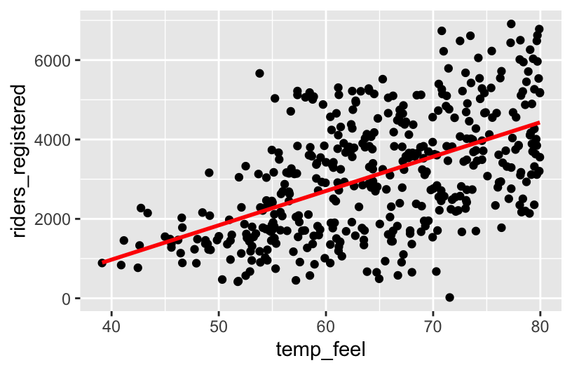

```r
ggplot(bikes_sub, aes(x = temp_feel, y = riders_registered)) +
    geom_point() +
    geom_smooth(method = "lm", color = "red", se = FALSE)
```

2. Use your model formula from the previous exercise to *predict* the ridership on August 17, 2012 from the temperature on that day. (That is, where do days with this temperature fall on the model trend line? How many registered riders would we *expect* on a 53.816 degree day?)

**Answer**

**-2486.41180 + 86.49251 * 53.816 = 2168.269**

3. Check your part b calculation using the `predict()` function. Take careful note of the syntax – there’s a lot going on!

```r
# What is the purpose of newdata = ___???
predict(bike_mod, newdata = data.frame(temp_feel = 53.816))
##        1
## 2168.269
```

4. Calculate the **residual** or **prediction error**. How far does the *observed* ridership fall from the *model prediction*?

**Answer**

residual = observed y - predicted y = 5665 - 2168.269 = 3496.731

5. Are positive residuals above or below the trend line? When we have positive residuals, does the model over- or under-estimate ridership? Repeat these questions for negative residuals.

**Answer**

- Positive residuals are above the trend line—we under-estimate ridership.
- Negative residuals are below the trend line—we over-estimate ridership.
6. For an 85 degree day, how many registered riders would we expect? Do you think it’s a good idea to make this prediction? (Revisit the visualization and filtering we did in Exercises 3 and 4.) [Complete after the class!]

## Exercise 7: Changing temperature units (CHALLENGE) [Complete after the class!]

Suppose we had measured temperature in degrees Celsius rather than degrees Fahrenheit. How do you think our intercept and slope estimates, and their coefficient interpretations, would change?

## Render your work Again (this is a good practice to render often- to see which part of the paragraph might cause non-rendering, if applicable!) [Complete after the class!]

- Click the “Render” button in the menu bar for this pane (blue arrow pointing right). This will create an HTML file containing all of the directions, code, and responses from this activity. A preview of the HTML will appear in the browser.
- Scroll through and inspect the document to check that your work translated to the HTML format correctly.
- Close the browser tab.
- Go to the “Background Jobs” pane in RStudio and click the Stop button to end the rendering process.
- Navigate to your “Activities” subfolder within your “STAT155” folder and locate the HTML file. You can open it again in your browser to double check.

# Additional Practice [Complete after class]

## Exercise 8: Ridership and windspeed

Let’s pull together everything that you’ve practiced in the preceding exercises to investigate the relationship between `riders_registered` and `windspeed`. Go back to using the `bikes` dataset (instead of `bikes_sub`) because we no longer need to only keep days less than 80 degrees.

```r
# Construct and interpret a visualization of this relationship
# Include a representation of the relationship trend


# Use lm to construct a model of riders_registered vs windspeed
# Save this as bike_mod2


# Get a short summary of this model
```

1. Summarize your observations from the visualizations.
2. Write out a formula for the model trend.
3. Interpret both the intercept and the windspeed coefficient. (Note: What does a negative slope indicate?)
4. Use this model to predict the ridership on August 17, 2012 and calculate the corresponding residual. (Note: You’ll first need to find the windspeed on this date!)

## Exercise 9: Data drills (`filter`, `select`, `summarize`) [Complete after class]

This exercise is designed to help you keep building your `dplyr` skills. These skills are important to data cleaning and digging, which in turn is important to really making meaning of our data. We’ll work with a simpler set of 10 data points:

```r
new_bikes <- bikes %>%
    select(date, temp_feel, humidity, riders_registered, day_of_week) %>%
    head(10)
```

### Verb 1: `summarize`

Thus far, in the `dplyr` grammar you’ve seen 3 **verbs** or action words: `summarize()`, `select()`, `filter()`. Try out the following code and then summarize the point of the `summarize()` function:

```r
new_bikes %>%
    summarize(mean(temp_feel), mean(humidity))
## # A tibble: 1 × 2
##   `mean(temp_feel)` `mean(humidity)`
##               <dbl>            <dbl>
## 1              52.0            0.544
```

### Verb 2: `select`

Try out the following code and then summarize the point of the `select()` function:

```r
new_bikes %>%
    select(date, temp_feel)
## # A tibble: 10 × 2
##    date       temp_feel
##    <date>         <dbl>
##  1 2011-01-01      64.7
##  2 2011-01-02      63.8
##  3 2011-01-03      49.0
##  4 2011-01-04      51.1
##  5 2011-01-05      52.6
##  6 2011-01-06      53.0
##  7 2011-01-07      50.8
##  8 2011-01-08      46.6
##  9 2011-01-09      42.5
## 10 2011-01-10      45.6
```

```r
new_bikes %>%
    select(-date, -temp_feel)
## # A tibble: 10 × 3
##    humidity riders_registered day_of_week
##       <dbl>             <dbl> <chr>
##  1    0.806               654 Sat
##  2    0.696               670 Sun
##  3    0.437              1229 Mon
##  4    0.590              1454 Tue
##  5    0.437              1518 Wed
##  6    0.518              1518 Thu
##  7    0.499              1362 Fri
##  8    0.536               891 Sat
##  9    0.434               768 Sun
## 10    0.483              1280 Mon
```

### Verb 3: `filter`

Try out the following code and then summarize the point of the `filter()` function:

```r
new_bikes %>%
    filter(riders_registered > 850)
## # A tibble: 7 × 5
##   date       temp_feel humidity riders_registered day_of_week
##   <date>         <dbl>    <dbl>             <dbl> <chr>
## 1 2011-01-03      49.0    0.437              1229 Mon
## 2 2011-01-04      51.1    0.590              1454 Tue
## 3 2011-01-05      52.6    0.437              1518 Wed
## 4 2011-01-06      53.0    0.518              1518 Thu
## 5 2011-01-07      50.8    0.499              1362 Fri
## 6 2011-01-08      46.6    0.536               891 Sat
## 7 2011-01-10      45.6    0.483              1280 Mon
```

```r
new_bikes %>%
    filter(day_of_week == "Sat")
## # A tibble: 2 × 5
##   date       temp_feel humidity riders_registered day_of_week
##   <date>         <dbl>    <dbl>             <dbl> <chr>
## 1 2011-01-01      64.7    0.806               654 Sat
## 2 2011-01-08      46.6    0.536               891 Sat
```

```r
new_bikes %>%
    filter(riders_registered > 850, day_of_week == "Sat")
## # A tibble: 1 × 5
##   date       temp_feel humidity riders_registered day_of_week
##   <date>         <dbl>    <dbl>             <dbl> <chr>
## 1 2011-01-08      46.6    0.536               891 Sat
```

## Exercise 10: Your turn [Complete after the class!]

Use `dplyr` verbs to complete each task below.

```r
# Keep only information about the humidity and day of week

# Keep only information about the humidity and day of week using a different approach

# Keep only information for Sundays

# Keep only information for Sundays with temperatures below 50

# Calculate the maximum and minimum temperatures
```

# Additional Exercises [complete after class- good for practice- you don’t need to submit it!]

**Context:** We’ll explore data from a weighlifting competition. The data originally came from [Kaggle](https://www.kaggle.com/open-powerlifting/powerlifting-database) and [OpenPowerlifting](https://www.openpowerlifting.org/). Our main goal will be to explore the relationship between strength-to-weight ratio (SWR) and body weight. Read in the data below.

```r
# Load packages and import data
library(readr)
library(ggplot2)
library(dplyr)

lifts <- read_csv("https://mac-stat.github.io/data/powerlifting.csv")
```

## Exercise 1: Get to know the data

1. Create a new code chunk by clicking the green “C” button with a green + sign in the top right of the menu bar. In this code chunk, use an appropriate function to look at the first few rows of the data.
2. Create a new code chunk, and use an appropriate function to learn how much data we have (in terms of cases and variables).
3. What does a case represent?
4. Navigate to the [FAQ page](https://www.openpowerlifting.org/faq) and read the response to the “How does this site work? Do you just download results from the federations?” question. What do you learn about data quality and completeness from this response?